# Practical Machine Learning Course Project

Aleksandr Kosukhin

June $10^{th}$, 2016

## Introduction

This work is aimed to partially replicate the work of *Velloso et al* in solving a problem of qualitative activity recognition of weight lifting excercises. The quality of exercise activity was formalised by choosing $4$ frequent incorrect ways of doing unilateral dumbbell biceps curl and the $5^{th}$ correct way. With this formalisation the problem became a classification problem and could be solved with the means of machine learning.

## Read Data

The data for this work are the subset of original data available [here](http://groupware.les.inf.puc-rio.br/har)

The data are readings of 4 on-body sensors: on arm, forearm, dumbbell and belt.

```r
trainUrl <- "https://d396qusza40orc.cloudfront.net/predmachlearn/pml-training.csv"
testUrl <- "https://d396qusza40orc.cloudfront.net/predmachlearn/pml-testing.csv"
download.file(trainUrl, "pml-training.csv")
download.file(testUrl, "pml-testing.csv")
```

```r
training <- read.csv("pml-training.csv")
testing <- read.csv("pml-testing.csv")
```

## Data Structure

```r
dim(training)
```

```
## [1] 19622   160
```

```r
str(training[, 1:10])
```

```
## 'data.frame':    19622 obs. of  10 variables:
##  $ X                   : int  1 2 3 4 5 6 7 8 9 10 ...
##  $ user_name           : Factor w/ 6 levels "adelmo","carlitos",..: 2 2 2 2 2 2 2 2 2 2 ...
##  $ raw_timestamp_part_1: int  1323084231 1323084231 1323084231 1323084232 1323084232 1323084232 1323084232 1323084232 1323084232 1323084232 ...
##  $ raw_timestamp_part_2: int  788290 808298 820366 120339 196328 304277 368296 440390 484323 484434 ...
##  $ cvtd_timestamp      : Factor w/ 20 levels "02/12/2011 13:32",..: 9 9 9 9 9 9 9 9 9 9 ...
##  $ new_window          : Factor w/ 2 levels "no","yes": 1 1 1 1 1 1 1 1 1 1 ...
##  $ num_window          : int  11 11 11 12 12 12 12 12 12 12 ...
##  $ roll_belt           : num  1.41 1.41 1.42 1.48 1.48 1.45 1.42 1.42 1.43 1.45 ...
##  $ pitch_belt          : num  8.07 8.07 8.07 8.05 8.07 8.06 8.09 8.13 8.16 8.17 ...
##  $ yaw_belt            : num  -94.4 -94.4 -94.4 -94.4 -94.4 -94.4 -94.4 -94.4 -94.4 -94.4 ...
```

It is seen that the data are time series and this should influence the cross validation procedure. Also the ‘X’ column is just an index and should not be included into the predictors set.

```r
chrono <- order(training[, 3], training[, 4])
training <- training[chrono,]
```

## Feature Selection

The data contain raw readings of sensors and derivatives from them. We just exclude near zero features.

```r
library(caret)
nzv <- nearZeroVar(training[, -dim(training)[2]])
length(nzv)
```

```
## [1] 60
```

## Model Algorithm

Because of the characteristic noise in the sensor data, a Random Forest approach was used.

```r
fitControl <- trainControl(## Time series data
                            method = "timeslice",
                            initialWindow = 100,
                            horizon = 25,
                            fixedWindow = TRUE)
```

```r
set.seed(2704)
modelFit <- train(classe ~ ., data = training[, -c(1, nzv)],
                    method = "rf",
                    ##trControl = fitControl,
                    verbose = FALSE
                  )
```

## Model result

[output not shown]

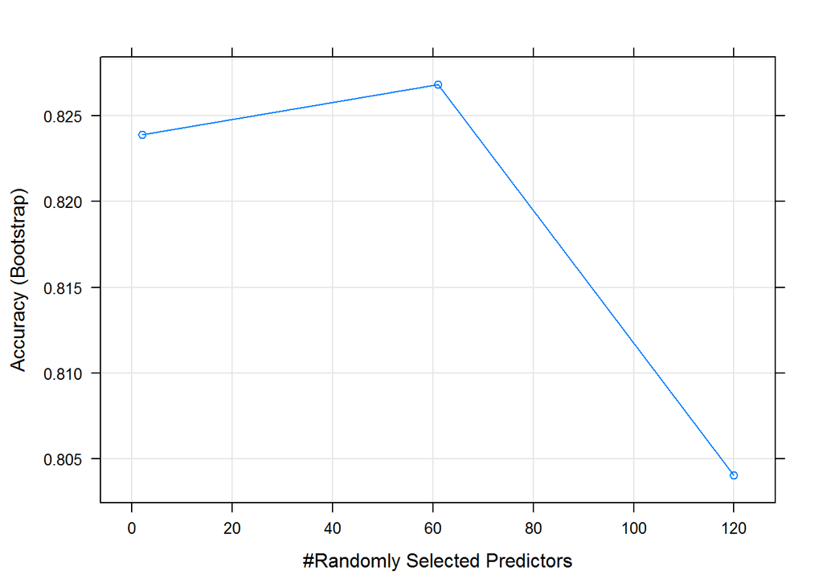